# causal_forest

2026-03-07

# Estimating Heterogeneous Gender Wage Gaps Non-Parametrically with Causal Forests

Causal Forest is a tree-based approach to estimating CATEs. It was developed through several papers by Athey, Wager and co-authors (Athey & Imbens, 2016; Wager & Athey, 2018; Nie & Wager, 2020; Athey et al., 2019). Its estimates are asymptotically unbiased and normal.

Causal forest removes confounding with nuisance models, fits a model to cluster observations with treatment effect heterogeneity to form an adaptive kernel and then it estimates out treatment effects within each kernel bandwidth. For this, it uses three models: a nuisance model that predicts treatment, a nuisance model that predicts outcome and finally a model of treatment effect heterogeneity. These nuisance models are normally regression forests that can be used to partial out selection effects and obtained the residualised treatment and outcome variable.
$$\check{Y} = Y - \hat{m}(x), \qquad
\check{D} = D - \hat{e}(x)$$
The final heterogeneity model is a random forest made up of causal trees (Athey & Imbens, 2016). Firstly, they use a splitting criterion that maximises treatment effect heterogeneity. Secondly they are ’honest’, meaning each tree uses typically half of its sample to split the tree and the other half to make estimates for each terminal node. This prevents over-fitting, giving asymptotically normal predictions out of each tree. The overall ensemble these fit into is trained as an R-Learner meta-learner (Nie & Wager, 2020).

Causal forest uses the ensemble as an adaptive kernel, finding weights to calculate treatment effects for neighbourhoods in a high-dimensional covariate space. We find the weights for a covariate set x by looking through each data-point i and finding the proportion of trees that were not fit on Xi (to prevent overfitting) for which Xi and x fall into the same leaf.

$$\alpha_i(x) =
\frac{1}{B}
\sum_{b=1}^{B}
\frac{\mathbb{1}(\{X_i \in L_b(x), i \in \mathcal{S}_b\})}
{|\{i : X_i \in L_b(x), i \in \mathcal{S}_b\}|}$$

In order to estimate treatment effects, it uses a weighted version of Robinson’s transformation as proposed by Athey et al. (2019). They are the solution to the following equation :
$$\sum_{i=1}^{n}
\alpha_i(x)
(\check{Y}_i - \tau(x)\check{D}_i)\check{D}_i = 0$$

Standard errors can be calculated via a bootstrap of little bags. This is done by dividing trees into small subforests, each of them built on different subsamples and estimating prediction variance across these subforests.

## Non-Parametric Estimation of Heterogeneous Gender Wage Gaps

This notebook expores heterogeneity in the gender wage gap in France. It estimates conditional average treatment effect of being a women on log wages across the covariate space using a causal forest. Thecovariates include the number of hours worked, the contract duration, age, region, sector, socio-professional categories and type of contract.

## Set up

```r
library(readr)
library(dplyr)
```

```r
library(grf)
library(ggplot2)
library(xtable)
library(purrr)
```

```r
data_bach <- read_csv("https://media.githubusercontent.com/media/AnahiRM/Gender-Wage-Gap-Heterogeneity-in-France/refs/heads/main/data/processed/sample_dataset.csv" )
data_bach <- data_bach %>%
  filter(y<10.3889953683178) %>% # Filter highest incomes due to discontinuities in data
  mutate(CS=as.factor(CS), REGR=as.factor(REGR))
```

## Estimating Gender Wage Gap

### Training Casual Forest

We train a causal forest using as treatment variable female. Given the descriptive rather than predictive nature of the analysis, no train test split is done to train the model.

```r
# Covariates
X_grf <- model.matrix(
  ~ -1
  + NBHEUR + DUREE + AGE + REGR  +
    A6 + CS + CONT_TRAV,
  data = data_bach
)
X_grf <- X_grf[, which(apply(X_grf, 2, var) != 0)] # exclude all constant variables

# Treatment
D <- data_bach$female==1

# Outcome
Y_grf <- data_bach$y


dim(X_grf)
```

[1] 463882 55

Our final sample contains 463882 subjects and 55 covariates.

```r
#cf <- causal_forest(
#  X = X_grf,
#  Y = Y_grf,
#  W = D,
#  num.trees = 1000,
#  num.threads = 16
#)
#saveRDS(cf, "my_causal_forest.rds") # Save causal forest as n R object for later use
```

The grf package allows a direct estimation of both ATE effects as well as to individual estimates of the gender wage gap in the sample.

### ATE Estimations

We estimate first the average gender effects on wages tryingseveral estimation methods and samples to check the robustness of the estimate. Methods include augmented inverse probability weighting and targeted maximum likelihood estimation. We run both methods on the whole sample as well as on the overlapping sample.

[output not shown]

```r
cat("---AIPW (Augmented Inverse Probability Weighting):---\n")
```

—AIPW (Augmented Inverse Probability Weighting):—

```r
print(ate_aipw)
```

```
estimate      std.err
```

-0.043266091 0.001168922

```r
cat("\n---TMLE (Targeted Maximum Likelihood Estimation):---\n")
```

—TMLE (Targeted Maximum Likelihood Estimation):—

```r
print(ate_tmle)
```

estimate std.err -0.04331068 0.00107189

```r
cat("\n--- Overlap Weighted Estimators  ---\n")
```

— Overlap Weighted Estimators —

```r
cat("AIPW with Overlap Weights:\n")
```

AIPW with Overlap Weights:

```r
print(ate_aipw_overl)
```

```
 estimate       std.err
```

-0.0376815099 0.0006114425

```r
cat("\nTMLE with Overlap Weights:\n")
```

TMLE with Overlap Weights:

```r
print(ate_tmle_overl)
```

[output not shown]

The estimated wage gap in the sample is around 3.8% and 4.3%, with the lower estimates found in the overlapped sample.

### Individual Gender Wage Gap Estimates

We then obtain individual predictions of gender wage gaps in the sample.

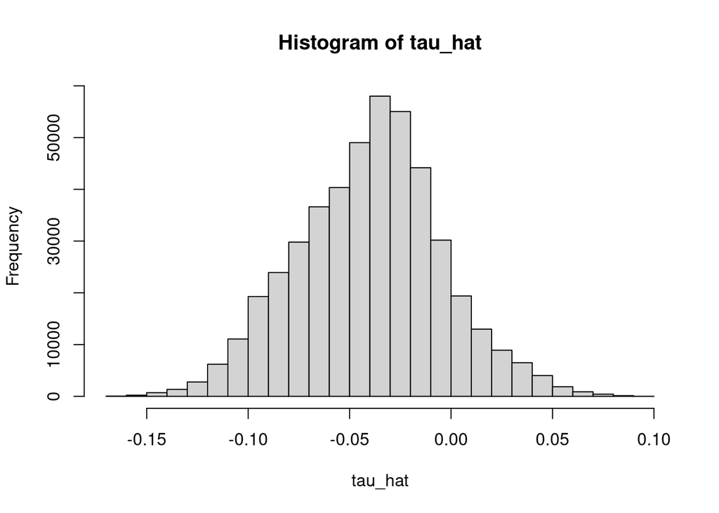

```r
predictions <-  predict(cf, X_grf, estimate.variance=TRUE)
tau_hat <- predictions$predictions
standard.error <-  sqrt(predictions$variance.estimates)

hist(tau_hat)
```

The histogram suggests individual gender wage gap estimates are considerably well behaved, with higher density in negative estimates.

## Gender Wage Gap Heterogeneity

This section analyzes what individual estimates reveal of gender wage gap heterogeneities. We first plot ranked estimates.

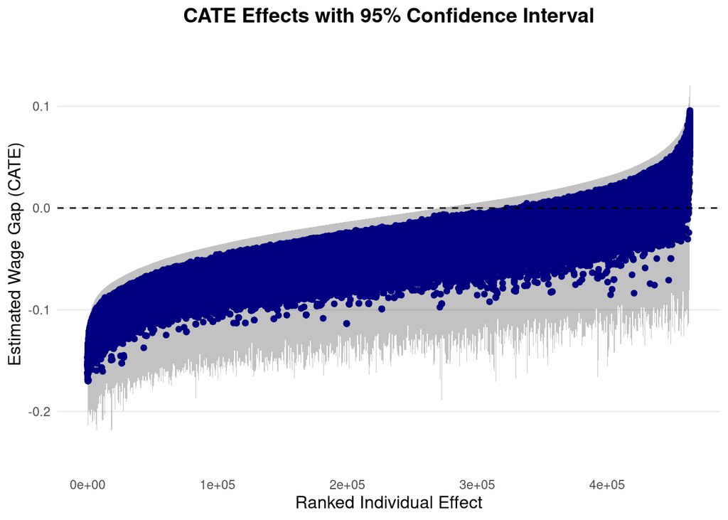

```r
df <- data.frame(
  tau_hat = tau_hat,
  se = standard.error
)
# CI bounds
df$upper <- df$tau_hat + 1.96 * df$se
df$lower <- df$tau_hat - 1.96 * df$se


df$percentile <- rank(df$upper) # rank acc. upper bound

df$is_significant <- df$upper < 0 # identify significant estimates
# Plot
ggplot(df, aes(x = percentile, y = tau_hat)) +
     geom_ribbon(aes(ymin = lower, ymax = upper), alpha = 0.3) +
      geom_point(color = "navy") +
      geom_hline(yintercept = 0, linetype = "dashed", color = "black") +
       labs(x = "Rank of Individual Effect", y = "Estimated Wage Gap (CATE)") +
       theme_minimal() +
  labs(x = "Ranked Individual Effect",
                y = "Estimated Wage Gap (CATE)",
                title = "CATE Effects with 95% Confidence Interval") +

   theme(
         plot.title = element_text(size = 14, face = "bold", hjust = 0.5),
        axis.title = element_text(size = 12),
        panel.grid.minor = element_blank(),
        panel.grid.major.x = element_blank()   )
```

This figure shows that significant heterogeneity in gender wage gap exists in France. In particular, 58.58% of the sample has an estimated gender wage gap significantly below zero at the 0.05 significance level. The remaining 41.42% do not present a statistically different from zero gender pay gap.

### Feature Importance : Understanding Drivers of Heterogeneity

We analyze covariates contributions to explaining heterogeneity in the gender pay gap. These do not correspond to the predictors of gap but rather the factors that differentiate groups of individuals which are similar in the estimated gap and different from others.

```r
vars <- colnames(X_grf) # Keep var names

# Run feature importance
var_importance <- variable_importance(cf)
rownames(var_importance) <- vars # Recover var names
# Format data
feature_importance <- data.frame(Variable=rownames(var_importance), Importance=as.numeric(var_importance[,1]) )

feature_importance <- feature_importance %>%
  filter(Importance>0) %>%
  arrange(desc(Importance))
print(feature_importance)
```

```
   Variable   Importance
```

1 CS62 3.126732e-01 2 CS43 1.607563e-01 3 A6BE 1.530608e-01 4 A6OQ 1.344637e-01 5 NBHEUR 4.837858e-02 6 REGR11 3.280081e-02 7 AGE 3.269837e-02 8 CS67 1.531525e-02 9 A6JU 1.508469e-02 10 CS52 1.235277e-02 11 REGR52 1.127319e-02 12 CS46 9.352445e-03 13 REGR32 8.617808e-03 14 A6GI 5.954607e-03 15 CS42 5.062314e-03 16 CS54 4.831304e-03 17 CS47 4.137227e-03 18 CS55 3.732091e-03 19 DUREE 3.641777e-03 20 REGR44 3.626354e-03 21 REGR84 3.442672e-03 22 REGR27 2.505387e-03 23 REGR75 2.479903e-03 24 CS56 2.414905e-03 25 REGR53 2.326768e-03 26 REGR24 2.042058e-03 27 REGR93 1.874024e-03 28 REGR76 1.785559e-03 29 REGR28 1.672078e-03 30 CS37 7.334353e-04 31 CS68 3.660579e-04 32 CONT_TRAVCDI 2.899423e-04 33 CS63 1.804715e-04 34 CS38 6.186210e-05 35 CS48 5.648069e-06 36 CS65 5.648069e-06

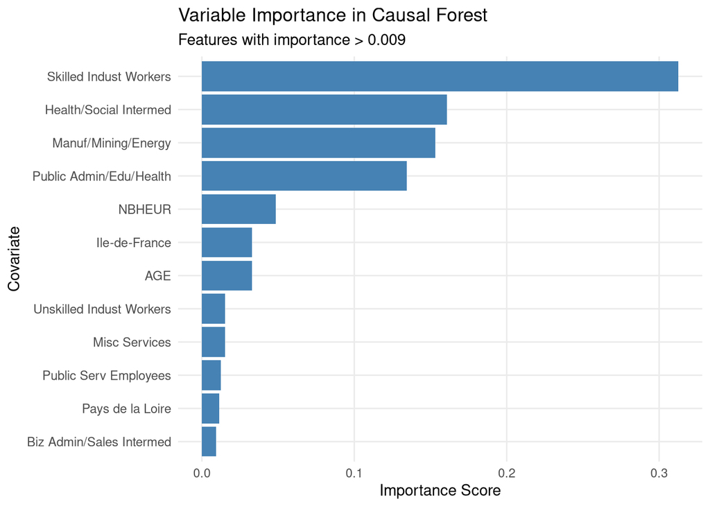

```r
feature_plot_data <- feature_importance %>%
  filter(Importance > 0.009) %>% # Filter most important variables
  arrange(desc(Importance))

# Rename variables
feature_plot_data <- feature_plot_data %>%
  mutate(Variable = ifelse(Variable %in% names(all_labels),
                           all_labels[Variable],
                           Variable))

#  Create the Importance Plot
ggplot(feature_plot_data, aes(x = reorder(Variable, Importance), y = Importance)) +
  geom_col(fill = "steelblue") + # Bars are better for importance (non-negative)
  coord_flip() +
  labs(
    title = "Variable Importance in Causal Forest",
    subtitle = "Features with importance > 0.009",
    x = "Covariate",
    y = "Importance Score"
  ) +
  theme_minimal() +
  theme(
    panel.grid.minor = element_blank(),
    axis.text.y = element_text(size = 9)
  )
```

Feature importance analysis suggests that socio-professional categories and industry play a primary role in explaining heterogeneity. In particular, skilled industrial workers and health and social workers appear as the two top drivers of gender wage gap heterogeneity. Manufacturing industry and working in public administration/health and education follow. Factors relating to people’s career and experience, including hours of work and age, appear relevant as well. Finally, some geographical patterns emerge with two regions, Île de France and Pays de la Loire, contributing to explaining heterogeneous dynamics.

### Gender Wage Gap Across Relevant Categories

In this section, we explore descriptively how the estimated wage gap vary across covariates.

```r
data_bach$tau <- predictions$predictions # Add predictions to the main dataset
cat_vars <- c("CS", "A6", "REGR")

# Rename variables
data_bach <- data_bach %>%
  mutate(
    A6       = recode(A6, !!!A6_map),
    REGR     = recode(REGR, !!!REGR_map),
    CONT_TRAV = recode(CONT_TRAV, !!!CONT_TRA_map),
    CS       = recode(CS, !!!CS_map)
  )

# Loop through categorical variables, plot mean estimate by category
plots <- map(cat_vars, function(var) {

  summary_df <- data_bach %>%
    group_by(across(all_of(var))) %>%
    summarise(mean_tau = mean(tau, na.rm = TRUE)) %>%
    ungroup()



  p <- ggplot(summary_df, aes(x = reorder(!!sym(var), mean_tau), y = mean_tau)) +
    geom_segment(aes(xend = !!sym(var), y = 0, yend = mean_tau), color = "skyblue", size = 1.2) +
    geom_point(color = "blue", size = 3) +
    coord_flip() +
    labs(x = var, y = expression(hat(tau)), title = paste("Mean tau by", var)) +
    theme_minimal()

  return(p)
})
```

```r
plots
```

[[1]]

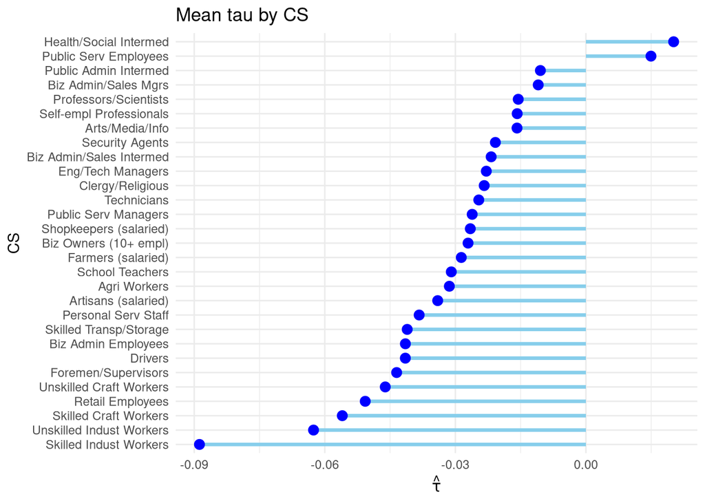

[[2]]

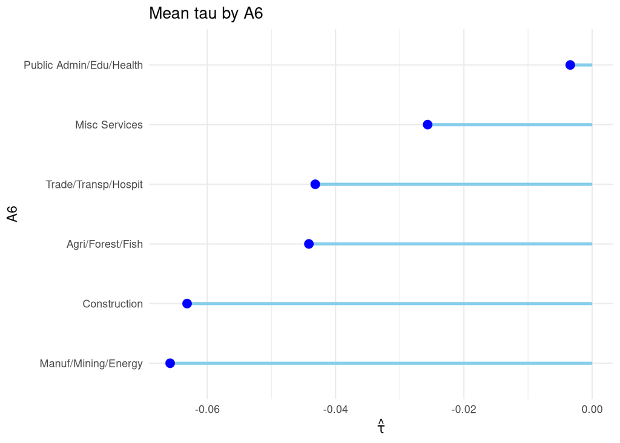

[[3]]

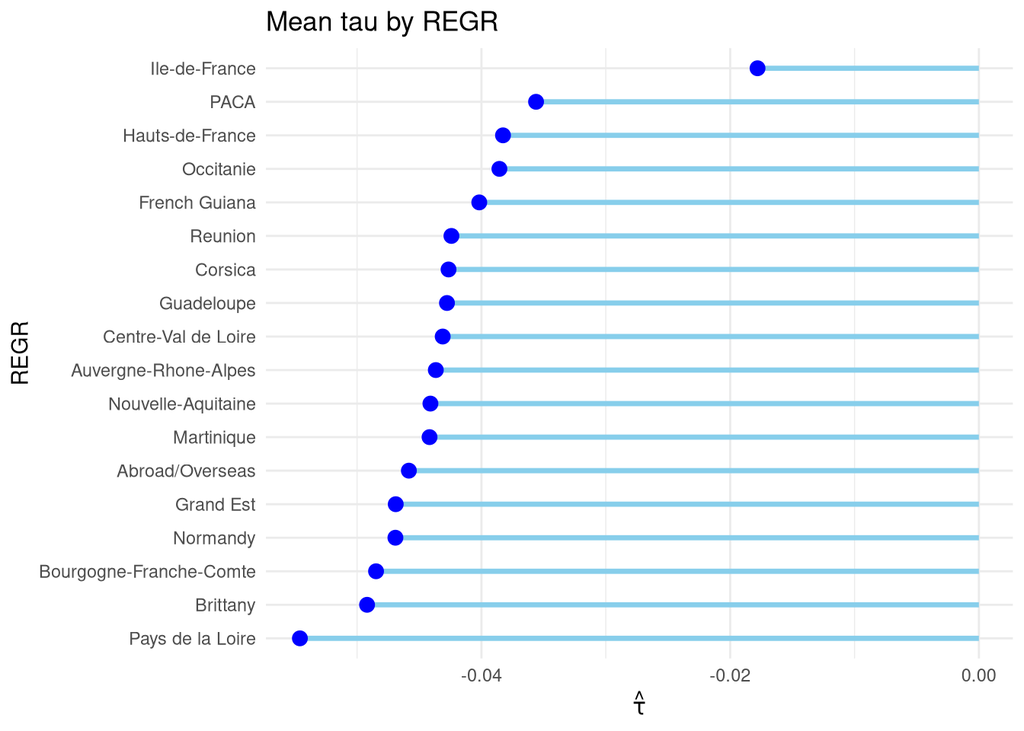

- **Socioprofessional category :** The only two categories in which women present, on average, an advantage is those women working in health and social sectors (2.12%) and public service employees (+1.4%). Women are particularly penalized in traditionally masculine categories in industry and manufacturing oriented sectors`(i.e., -8.85% in skilled industrial works). On average, the disadvantage that women face across socioprofessional categories is larger than any advantage they might enjoy.
- **Sector:** across all sectors, on average, women earn less than comparable men. The largest gaps appear in works in the secondary sector such as manufacturing (-6.56%), construction (-6.29%), agricultural (-4.32%) and trade and transports (-4.31%). The gap is significantly lower in the service sectors (-0.353% in public administration, education and health and -2.56% in misc services).
- **Regions :** Gender wage gaps present relatively similar magnitudes across the French territory with the exception of the Île de France and Pays de la Loire regions, which present the lowest (-1.78%) and highest (-5.44%) estimated average gender wage gap.

```r
num_vars <- c("AGE", "NBHEUR")

# Loop through numeric variables and plot scatter plot
plots_num <- map(num_vars, function(var) {

  p <- ggplot(data_bach, aes(x = !!sym(var), y = tau)) +
    geom_point(color = "darkorange", alpha = 0.6) +
    geom_smooth(method = "lm", se = TRUE, color = "blue") +
    labs(
      x = var,
      y = expression(tau),
      title = paste("Scatter plot of tau vs", var)
    ) +
    theme_minimal()

  return(p)
})
```

```r
plots_num
```

[[1]]

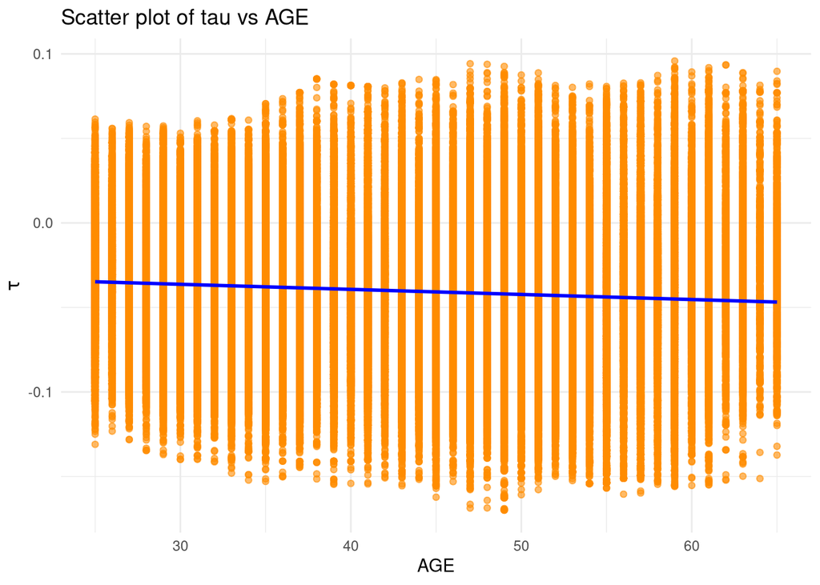

[[2]]

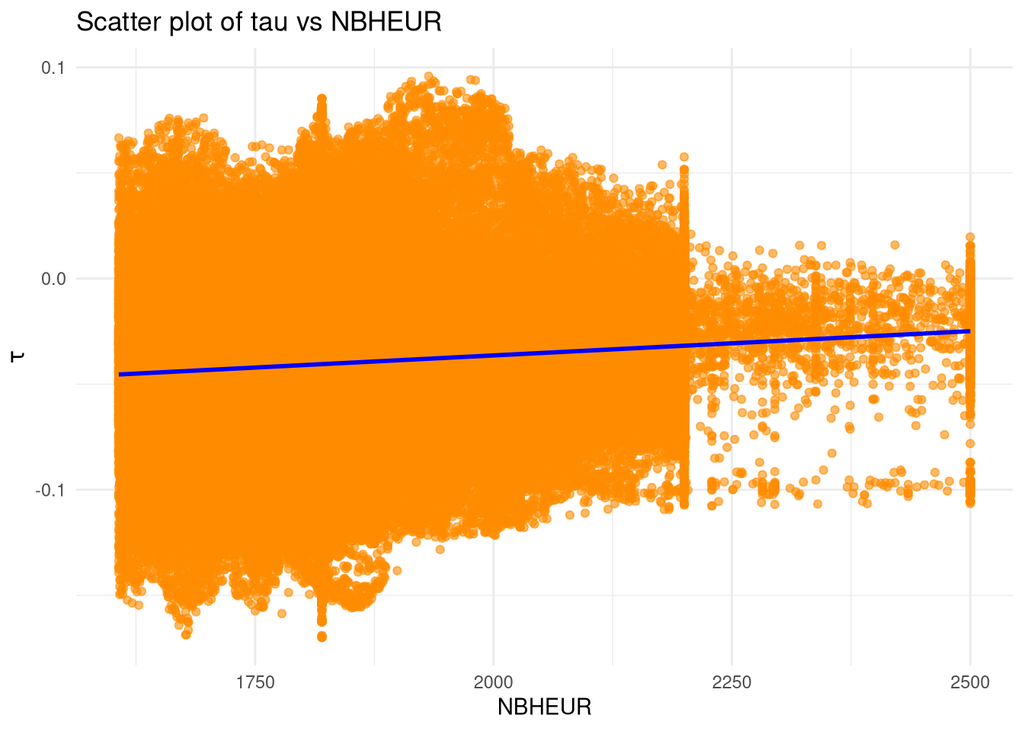

### Best Linear Projections : Gender Wage Gap in the Covariate Space

```r
# Run best linear projections
coeffs <- best_linear_projection(cf, A=X_grf, vcov.type="HC0")
print(coeffs)
```

Best linear projection of the conditional average treatment effect. Confidence intervals are cluster- and heteroskedasticity-robust (HC0):

```
            Estimate  Std. Error t value Pr(>|t|)
```

(Intercept) -2.1017e-01 8.2744e-02 -2.5400 0.011086 *  
NBHEUR 5.2028e-05 1.3906e-05 3.7414 0.000183 DUREE -1.2487e-04 8.9558e-05 -1.3943 0.163217  
AGE -5.3575e-05 1.1357e-04 -0.4717 0.637120  
REGR1 2.4818e-02 2.2796e-02 1.0887 0.276284  
REGR2 3.4716e-02 3.2622e-02 1.0642 0.287247  
REGR3 1.0904e-02 3.2112e-02 0.3396 0.734189  
REGR4 2.2259e-02 2.2239e-02 1.0009 0.316864  
REGR11 2.1074e-02 1.8185e-02 1.1589 0.246508  
REGR24 8.9429e-03 1.8636e-02 0.4799 0.631308  
REGR27 -1.1087e-02 1.8897e-02 -0.5867 0.557393  
REGR28 6.6417e-04 1.8581e-02 0.0357 0.971486  
REGR32 7.9701e-03 1.8579e-02 0.4290 0.667926  
REGR44 -1.3716e-03 1.8365e-02 -0.0747 0.940465  
REGR52 -1.0123e-02 1.8313e-02 -0.5528 0.580407  
REGR53 -5.1467e-03 1.8453e-02 -0.2789 0.780319  
REGR75 -2.4004e-03 1.8324e-02 -0.1310 0.895777  
REGR76 8.4305e-04 1.8380e-02 0.0459 0.963415  
REGR84 2.4034e-03 1.8200e-02 0.1321 0.894945  
REGR93 4.4408e-03 1.8350e-02 0.2420 0.808777  
REGR94 1.5102e-02 2.5789e-02 0.5856 0.558158  
A6BE 4.1133e-02 2.3429e-02 1.7556 0.079152 .  
A6FZ 2.7507e-02 2.4372e-02 1.1286 0.259050  
A6GI 4.8937e-02 2.3357e-02 2.0951 0.036159  
A6JU 6.0624e-02 2.3292e-02 2.6028 0.009247 A6OQ 6.8121e-02 2.3579e-02 2.8890 0.003864 ** CS21 1.5201e-01 7.6225e-02 1.9942 0.046126 *  
CS22 9.8720e-02 7.0345e-02 1.4034 0.160509  
CS23 9.3691e-02 7.2014e-02 1.3010 0.193255  
CS31 1.9382e-01 7.3244e-02 2.6462 0.008141 ** CS33 1.2018e-01 6.8671e-02 1.7501 0.080106 .  
CS34 1.3832e-01 6.9644e-02 1.9861 0.047024 *  
CS35 1.1037e-01 6.9630e-02 1.5850 0.112957  
CS37 1.0902e-01 6.8011e-02 1.6029 0.108953  
CS38 1.0101e-01 6.8004e-02 1.4854 0.137443  
CS42 7.5549e-02 6.8212e-02 1.1076 0.268051  
CS43 1.3676e-01 6.8047e-02 2.0098 0.044452 *  
CS44 1.3745e-02 9.0587e-02 0.1517 0.879396  
CS45 1.2946e-01 6.8172e-02 1.8991 0.057553 .  
CS46 1.0076e-01 6.7963e-02 1.4826 0.138181  
CS47 1.0619e-01 6.7984e-02 1.5619 0.118310  
CS48 7.7315e-02 6.8164e-02 1.1343 0.256689  
CS52 1.2427e-01 6.8063e-02 1.8258 0.067875 .  
CS53 1.0040e-01 6.8358e-02 1.4688 0.141890  
CS54 7.7492e-02 6.7970e-02 1.1401 0.254248  
CS55 7.1769e-02 6.7996e-02 1.0555 0.291200  
CS56 7.4737e-02 6.8368e-02 1.0931 0.274329  
CS62 4.8313e-02 6.8133e-02 0.7091 0.478263  
CS63 5.4010e-02 6.8224e-02 0.7916 0.428565  
CS64 7.4145e-02 6.8085e-02 1.0890 0.276146  
CS65 8.5123e-02 6.8058e-02 1.2507 0.211029  
CS67 7.0208e-02 6.8099e-02 1.0310 0.302554  
CS68 5.4440e-02 6.8431e-02 0.7955 0.426296  
CS69 9.4515e-02 6.8490e-02 1.3800 0.167591  
CONT_TRAVCDI -1.7882e-02 7.3531e-03 -2.4319 0.015019 *  
— Signif. codes: 0 ‘**’ 0.001 ’**’ 0.01 ’’ 0.05 ‘.’ 0.1 ’ ’ 1

```r
# Convert to xtable and export
coef_mat_cf <- coeffs
pvals <- coef_mat_cf[,4]

stars <- ifelse(pvals < 0.01, "***",
                ifelse(pvals < 0.05, "**",
                       ifelse(pvals < 0.1, "*", "")))

estimates_with_stars_cf <- paste0(
  sprintf("%.3f", coef_mat_cf[,1]),
  stars
)
full_table_cf <- data.frame(
  Variable = rownames(coef_mat_cf),
  Estimate  = sprintf("%.3f",coef_mat_cf[,1]),
  Std.Error = sprintf("%.3f", coef_mat_cf[,2]),
  t.value   = sprintf("%.3f", coef_mat_cf[,3]),
  p.value   = sprintf("%.3f", coef_mat_cf[,4])
)
xt_cf <- xtable(full_table_cf)

print(xt_cf,
      type = "latex",
      file = "cf_full_table.tex",
      include.rownames = TRUE,
      sanitize.text.function = identity,  # IMPORTANT for stars
      booktabs = TRUE)
```

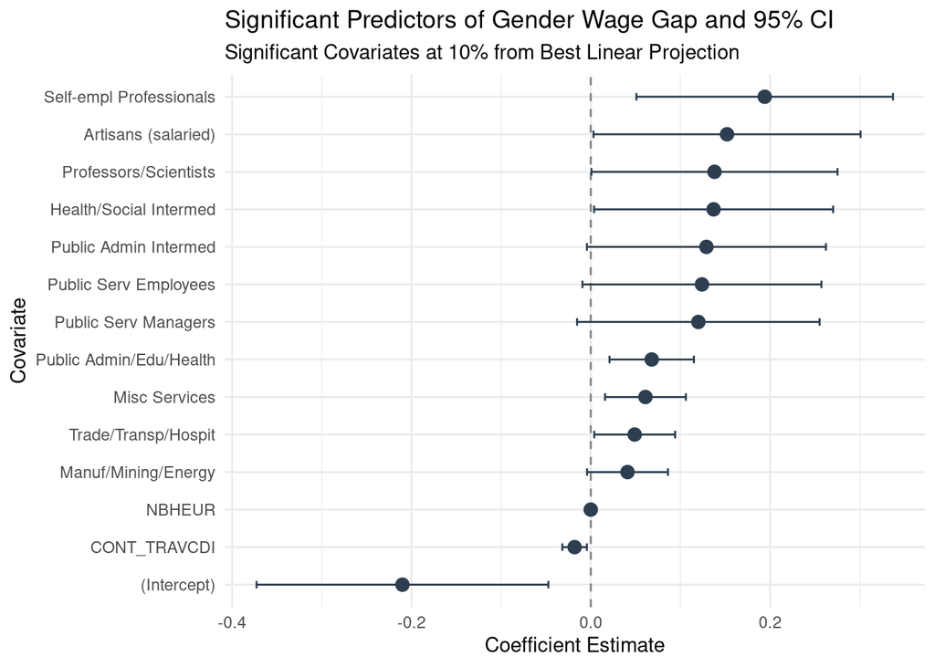

```r
#  Convert the grf output to a data frame for plotting
full_table_cf <- full_table_cf %>%
  mutate(Estimate=as.numeric(Estimate), Std.Error=as.numeric(Std.Error), t.value=as.numeric(t.value), p.value=as.numeric(p.value))

# Filter for significant coefficients
significant_coeffs <- full_table_cf %>%
  filter(p.value<0.1)

#  Rename variables
significant_coeffs <- significant_coeffs %>%
  mutate(Variable = ifelse(Variable %in% names(all_labels),
                           all_labels[Variable],
                           Variable))


#  Create the plot
ggplot(significant_coeffs, aes(x = reorder(Variable, Estimate), y = Estimate)) +
  geom_hline(yintercept = 0, linetype = "dashed", color = "gray50") +
  geom_point(color = "#2c3e50", size = 3) +
  geom_errorbar(aes(ymin = Estimate - 1.96 * Std.Error,
                    ymax = Estimate + 1.96 * Std.Error),
                width = 0.2, color = "#2c3e50") +
  coord_flip() +
  labs(
    title = "Significant Predictors of Gender Wage Gap and 95% CI",
    subtitle = "Significant Covariates at 10% from Best Linear Projection",
    x = "Covariate",
    y = "Coefficient Estimate"
  ) +
  theme_minimal()
```